# Introductory Machine Learning: Assignment 2

**Deadline:**

Assignment 2 is due Thursday, October 3 at 11:59pm. Late work will not be accepted as per the course policies (see the Syllabus and Course policies on [Canvas](https://canvas.yale.edu).

Sharing code or any written work is not okay, but discussing problems with the course staff or with other students is encouraged. Acknowledge any collaborations and source materials used.

You should start early so that you have time to get help if you're stuck. The drop-in office hours schedule can be found on [Canvas](https://canvas.yale.edu). You can also post questions or start discussions on [Ed Discussion](https://edstem.org/us/courses/44592/discussion/). The assignment may look long at first glance, but the problems are broken up into steps that should help you to make steady progress.

**Submission:**

Submit your assignment as a .pdf on Gradescope. You can access Gradescope through Canvas on the left-side of the class home page. The problems in each homework assignment are numbered. Note: When submitting on Gradescope, please select the correct pages of your pdf that correspond to each problem. This will allow graders to find your complete solution to each problem.

To produce the .pdf, please do the following in order to preserve the cell structure of the notebook:

1. Go to "File" at the top-left of your Jupyter Notebook
2. Under "Download as", select "HTML (.html)"
3. After the .html has downloaded, open it and then select "File" and "Print" (note you will not actually be printing)
4. From the print window, select the option to save as a .pdf

**Topics**

1. Logistic regression
2. Regularization
3. Stochastic gradient descent
4. Trees
5. Bias-variance tradeoff

## Problem 1: Penguins: An ice example (20 points)

Can you tell one penguin species from another? Let's put what we've learned about logistic regression to (a very cute) test!

[figure not shown]

We first need to learn a little about the anatomy of our flightless feathered friends. The *culmen* is the upper ridge of a bird’s bill.

[figure not shown]

In our dataset, the culmen length and depth are called `bill_length_mm` and `bill_depth_mm`.

*Data were collected and made available by [Dr. Kristen Gorman](https://www.uaf.edu/cfos/people/faculty/detail/kristen-gorman.php) and the [Palmer Station, Antarctica LTER](https://pallter.marine.rutgers.edu/), a member of the [Long Term Ecological Research Network](https://lternet.edu/). Artwork by @allison_horst.

```python
# run this cell to import needed packages
import pandas as pd
import numpy as np
from sklearn.model_selection import train_test_split
from sklearn.preprocessing import LabelEncoder
from sklearn.linear_model import LogisticRegression
import matplotlib.pyplot as plt
import seaborn as sns

%matplotlib inline
```

```python
# just run this cell to read in the data, and drop a couple variables

df = pd.read_csv('https://github.com/YData123/sds265-fa24/raw/main/assignments/assn2/penguins.csv')
df = df.drop(columns=['index','year','island'])
df = df.dropna(axis=0)
df
```

|  | species | bill_length_mm | bill_depth_mm | flipper_length_mm | body_mass_g | sex |
| --- | --- | --- | --- | --- | --- | --- |
| 0 | Adelie | 39.1 | 18.7 | 181.0 | 3750.0 | male |
| 1 | Adelie | 39.5 | 17.4 | 186.0 | 3800.0 | female |
| 2 | Adelie | 40.3 | 18.0 | 195.0 | 3250.0 | female |
| 4 | Adelie | 36.7 | 19.3 | 193.0 | 3450.0 | female |
| 5 | Adelie | 39.3 | 20.6 | 190.0 | 3650.0 | male |
| ... | ... | ... | ... | ... | ... | ... |
| 339 | Chinstrap | 55.8 | 19.8 | 207.0 | 4000.0 | male |
| 340 | Chinstrap | 43.5 | 18.1 | 202.0 | 3400.0 | female |
| 341 | Chinstrap | 49.6 | 18.2 | 193.0 | 3775.0 | male |
| 342 | Chinstrap | 50.8 | 19.0 | 210.0 | 4100.0 | male |
| 343 | Chinstrap | 50.2 | 18.7 | 198.0 | 3775.0 | female |

333 rows × 6 columns

```python
# Next we'll make the sex variable binary, and separate out
# species as the label to predict

species = list(set(df['species']))
df['class'] = LabelEncoder().fit_transform(df['species'])
sex = [int(list(df['sex'])[j]=='male') for j in range(len(df))]
df['sex'] = sex
df = df.drop(columns=['species'])
df
```

|  | bill_length_mm | bill_depth_mm | flipper_length_mm | body_mass_g | sex | class |
| --- | --- | --- | --- | --- | --- | --- |
| 0 | 39.1 | 18.7 | 181.0 | 3750.0 | 1 | 0 |
| 1 | 39.5 | 17.4 | 186.0 | 3800.0 | 0 | 0 |
| 2 | 40.3 | 18.0 | 195.0 | 3250.0 | 0 | 0 |
| 4 | 36.7 | 19.3 | 193.0 | 3450.0 | 0 | 0 |
| 5 | 39.3 | 20.6 | 190.0 | 3650.0 | 1 | 0 |
| ... | ... | ... | ... | ... | ... | ... |
| 339 | 55.8 | 19.8 | 207.0 | 4000.0 | 1 | 1 |
| 340 | 43.5 | 18.1 | 202.0 | 3400.0 | 0 | 1 |
| 341 | 49.6 | 18.2 | 193.0 | 3775.0 | 1 | 1 |
| 342 | 50.8 | 19.0 | 210.0 | 4100.0 | 1 | 1 |
| 343 | 50.2 | 18.7 | 198.0 | 3775.0 | 0 | 1 |

333 rows × 6 columns

### 1.1 Plotting the data

The following cell shows a scatter plot of all pairs of variables. We showed this type of plot in class for the California housing data. Describe several entries in this plot, and what it tells you about the the relationship between the pairs of covariates. Do the relationships make intuitive sense? Why or why not? Do the data appear to have any obvious outliers or unusual patterns? Why or why not?

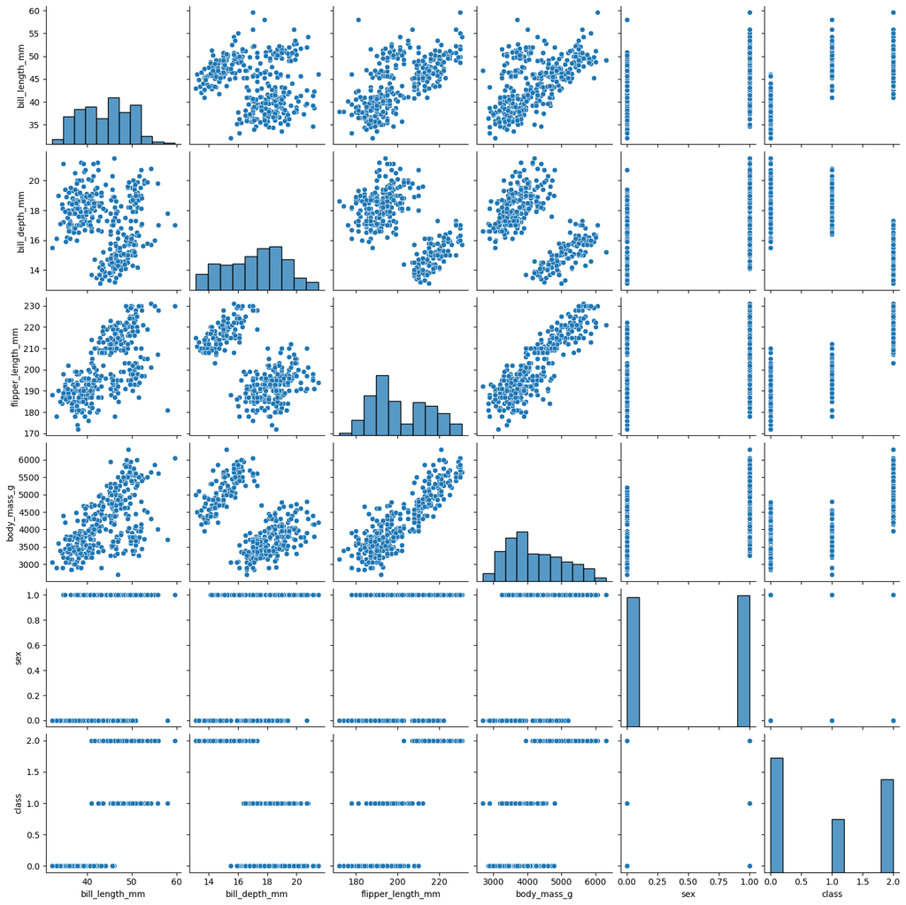

```python
_ = sns.pairplot(df)
```

I think the data does make intuitive sense. When plotting bill length against bill depth, flipper length, or body mass, it's pretty easy to see three clusters which I assume to be the 3 species of penguines. With just bill depth and flipper length or bill depth and body mass though, it seems like two of the clusters sort of blend together, which suggest that these combinations of variables are not very good classifiers for those two particular species, but good enough to tell apart the third. The body mass to flipper length ratio seems to be pretty constant across the different species as well. Overall I don't think anything is really unusual, since I can intuitively make sense of the patterns pretty well.

```python
def plot_features(df, feature1_name, feature2_name):
    fig = plt.figure(figsize=(8,6))
    ax = fig.add_subplot(111)
    colors = ['orange', 'pink', 'lightgreen']
    species = ['Adelie', 'Chinstrap', 'Gentoo']

    for c in range(3):
        mask = (df['class']==c)
        plt.scatter(df[feature1_name][mask],
                    df[feature2_name][mask],
                    color=colors[c], label=species[c])

    plt.xlabel(feature1_name)
    plt.ylabel(feature2_name)
    plt.legend(loc='upper left')
    plt.show()
```

### 1.1 Plotting the data (continued)

Next, using the `plot_features` function above, give additional plots of pairs of features, shown together with the class labels. An example of such a plot is shown below:

[figure not shown]

For each plot, discuss why the pair of features may or not be helpful in discriminating between the three species of penguins.

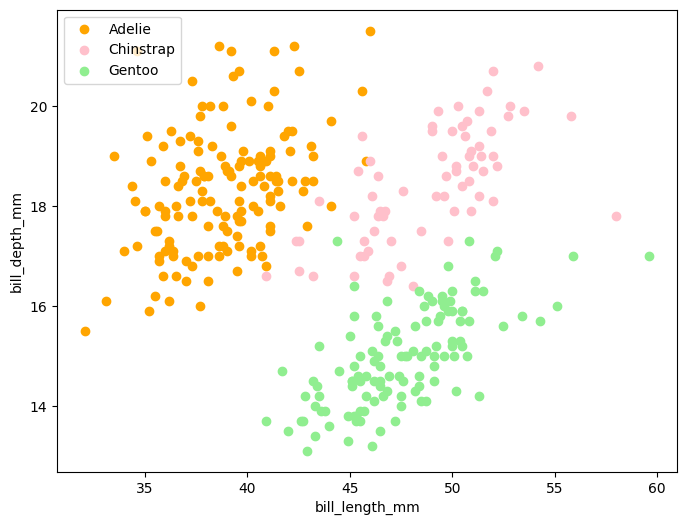

```python
# your code and markdown here
plot_features(df, 'bill_length_mm', 'bill_depth_mm')
```

Bill length and bill depth serves as a pretty good pair of features for the three species since the clusters are relatively discrete.

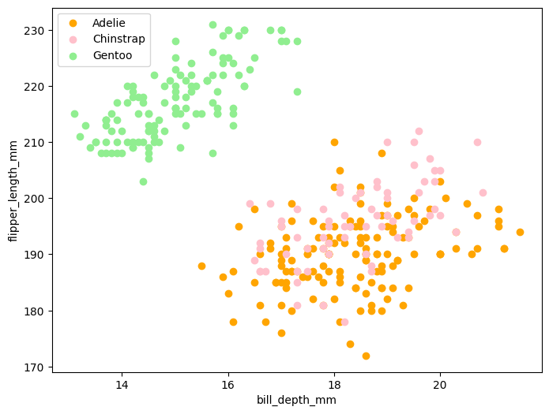

```python
plot_features(df, "bill_depth_mm", "flipper_length_mm")
```

Just as I suspected, the flipper length/bill depth combo isn't very good at telling two of the species apart. But it would be solid for telling the third one apart from the other two.

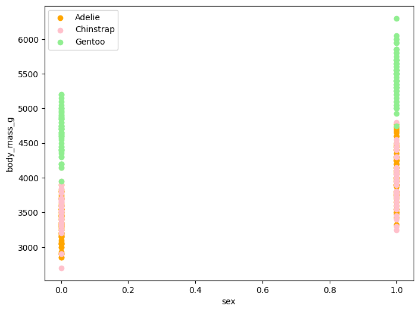

```python
plot_features(df, "sex", "body_mass_g")
```

Now I look at the sex/body mass graph, it's actually more interesting than I thought because the gap is actually significant. Again, could be a good classifier for telling Gentoo from the other two but not as good at telling apart Chinstrap and Adelie.

```python
# Just run the following cell, to get inputs X and labels y
y = np.array(df['class'])
X = df.copy()
X = X.drop(columns=['class'])
X
```

|  | bill_length_mm | bill_depth_mm | flipper_length_mm | body_mass_g | sex |
| --- | --- | --- | --- | --- | --- |
| 0 | 39.1 | 18.7 | 181.0 | 3750.0 | 1 |
| 1 | 39.5 | 17.4 | 186.0 | 3800.0 | 0 |
| 2 | 40.3 | 18.0 | 195.0 | 3250.0 | 0 |
| 4 | 36.7 | 19.3 | 193.0 | 3450.0 | 0 |
| 5 | 39.3 | 20.6 | 190.0 | 3650.0 | 1 |
| ... | ... | ... | ... | ... | ... |
| 339 | 55.8 | 19.8 | 207.0 | 4000.0 | 1 |
| 340 | 43.5 | 18.1 | 202.0 | 3400.0 | 0 |
| 341 | 49.6 | 18.2 | 193.0 | 3775.0 | 1 |
| 342 | 50.8 | 19.0 | 210.0 | 4100.0 | 1 |
| 343 | 50.2 | 18.7 | 198.0 | 3775.0 | 0 |

333 rows × 5 columns

### 1.2 Standardize the data

Next, standardize the data, so that each column of `X` has mean zero and standard deviation one. Note that after you have done this transformation, `X` should still be a `pandas.DataFrame`. Then, briefly explain why it is important to standardize the variables in the logistic regression models that you will train below.

```python
# Your code here
from sklearn.preprocessing import StandardScaler

scaler = StandardScaler()
X_scaled = scaler.fit_transform(X)
X = pd.DataFrame(X_scaled, columns=X.columns)
X.head()
```

|  | bill_length_mm | bill_depth_mm | flipper_length_mm | body_mass_g | sex |
| --- | --- | --- | --- | --- | --- |
| 0 | -0.896042 | 0.780732 | -1.426752 | -0.568475 | 0.991031 |
| 1 | -0.822788 | 0.119584 | -1.069474 | -0.506286 | -1.009050 |
| 2 | -0.676280 | 0.424729 | -0.426373 | -1.190361 | -1.009050 |
| 3 | -1.335566 | 1.085877 | -0.569284 | -0.941606 | -1.009050 |
| 4 | -0.859415 | 1.747026 | -0.783651 | -0.692852 | 0.991031 |

Standardization ensures that each feature contributes equally to the model. Features on different scales can lead to biased model coefficients.

### 1.3 Fit logistic regressions

As done in the class demo for mushrooms and iris flowers, you will now construct a series of logistic regression models using an increasing number of training points.

Specifically, we want you to:

- Vary the sample size from 10% of the data to 90% of the data, in increments of 10%
- For each sample size, train a logistic regression model on randomly selected training points, and test on the remaining data
- For each sample size, run 100 trials and average the error rates
- Plot the resulting average error rates as a function of sample percentage of the data

We will use the function sklearn.model_selection.train_test_split in each trial to randomly split the data into training and test sets.

Here we repeat exactly what we did during class using `lr = LogisticRegression(solver='lbfgs', multi_class='multinomial')` to fit a logistic regression model to predict the three species (*Adelie*, *Chinstrap*, and *Gentoo*).

After filling in your code, simply run this cell to plot a learning curve of error rate as a function of training percentage.

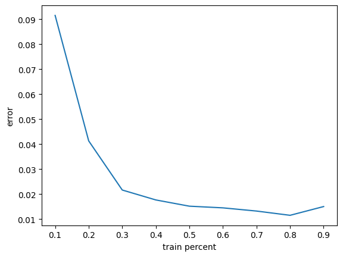

```python
from sklearn.metrics import accuracy_score

lr = LogisticRegression(penalty='l2', C=.1, multi_class='multinomial')

lr_error_rate = []
trials = 100
train_percent = np.linspace(.1, .9, 9)

# For each training set percentage, create train/test split accordingly
# and run logistic regression 100 times and calculate the average error rate

"""
function input:
  X: data
  y: label
  ratio: train data percentage
  trails: number of trails to run

function return:
  the average error rate with this train data percentage
"""

def get_err_rate(X, y, ratio, trials):
    # todo:
    # your code starts here
    errors = []

    for _ in range(trials):
        X_train, X_test, y_train, y_test = train_test_split(
            X, y, train_size=ratio, random_state=None
        )

        lr = LogisticRegression(
            penalty="l2", C=0.1, solver="lbfgs"
        )
        lr.fit(X_train, y_train)

        y_pred = lr.predict(X_test)

        error = 1 - accuracy_score(y_test, y_pred)
        errors.append(error)

    return np.mean(errors)
    # your code ends here

# Use get_err_rate to find the error rate for respective split size
for p in train_percent:
    lr_error_rate.append(get_err_rate(X, y, p, trials))


plt.plot(train_percent, lr_error_rate)
plt.xlabel('train percent')
plt.ylabel('error')
plt.show()
```

### 1.4 Choose good feature pairs

Which pair of variables gives the best predictions of the species of penguins? Run some experiments and report back below!

Note that there are ${5 \choose 2} = 10$ ways you can choose a pair of features. You may want to run a loop to automate this :)

```python
# todo:
# your code starts here
from itertools import combinations

features = [
    "bill_length_mm",
    "bill_depth_mm",
    "flipper_length_mm",
    "body_mass_g",
    "sex",
]

feature_pairs = list(combinations(features, 2))
pair_error_rate = {}
trials = 100
for pair in feature_pairs:
    X_pair = X[list(pair)]
    avg_error = get_err_rate(X_pair, y, ratio=0.8, trials=trials)
    pair_error_rate[pair] = avg_error

best_pair = min(pair_error_rate, key=pair_error_rate.get)
best_error_rate = pair_error_rate[best_pair]

print(
    f"The best feature pair is {best_pair} with an average error rate of {best_error_rate:.4f}"
)

for pair, error_rate in pair_error_rate.items():
    print(f"Feature pair {pair}: Average Error Rate = {error_rate:.4f}")
# your code ends here
```

```
The best feature pair is ('bill_length_mm', 'flipper_length_mm') with an average error rate of 0.0521
Feature pair ('bill_length_mm', 'bill_depth_mm'): Average Error Rate = 0.0640
Feature pair ('bill_length_mm', 'flipper_length_mm'): Average Error Rate = 0.0521
Feature pair ('bill_length_mm', 'body_mass_g'): Average Error Rate = 0.0685
Feature pair ('bill_length_mm', 'sex'): Average Error Rate = 0.2360
Feature pair ('bill_depth_mm', 'flipper_length_mm'): Average Error Rate = 0.1997
Feature pair ('bill_depth_mm', 'body_mass_g'): Average Error Rate = 0.2012
Feature pair ('bill_depth_mm', 'sex'): Average Error Rate = 0.2297
Feature pair ('flipper_length_mm', 'body_mass_g'): Average Error Rate = 0.2181
Feature pair ('flipper_length_mm', 'sex'): Average Error Rate = 0.2143
Feature pair ('body_mass_g', 'sex'): Average Error Rate = 0.2173
```

### 1.5 Visualize the decision boundries

Using the two features you chose as the best, and at least two additional pairs of features, visualize the decision boundries of the logistic regression models.

Is it what you expected? Where are you observing incorrect predictions? Describe why the decision boundaries make sense, from your understanding of the logistic regression model.

Use the function `plot_decision_boundaries` that we supply below. (You may also modify this function to your liking.) An example plot is shown here:

[figure not shown]

```python
def plot_decision_boundaries(X, y, model, error):
    X2 = np.array(X)
    b = model.intercept_
    beta = model.coef_.T
    colors = ['orange', 'pink', 'lightgreen']
    h = 0.015
    x_min, x_max = X2[:, 0].min() - .5, X2[:, 0].max() + .5
    y_min, y_max = X2[:, 1].min() - .5, X2[:, 1].max() + .5
    xx, yy = np.meshgrid(np.arange(x_min, x_max, h),
                         np.arange(y_min, y_max, h))
    Z = np.dot(np.c_[xx.ravel(), yy.ravel()], beta) + b
    Z = np.argmax(Z, axis=1)
    Z = Z.reshape(xx.shape)
    fig = plt.figure(figsize=(8,8))
    plt.contourf(xx, yy, Z, levels=[0,.5,1.5,2.5], colors=colors, alpha=0.5)
    for c in range(3):
        mask = (y==c)
        plt.scatter(X2[np.array(mask),0], X2[np.array(mask),1], color=colors[c], label=species[c])

    plt.xlim(xx.min(), xx.max())
    plt.ylim(yy.min(), yy.max())
    plt.legend(loc='upper left')
    plt.title('error rate: %.2f' % error)
    plt.xlabel(X.columns[0])
    plt.ylabel(X.columns[1])
```

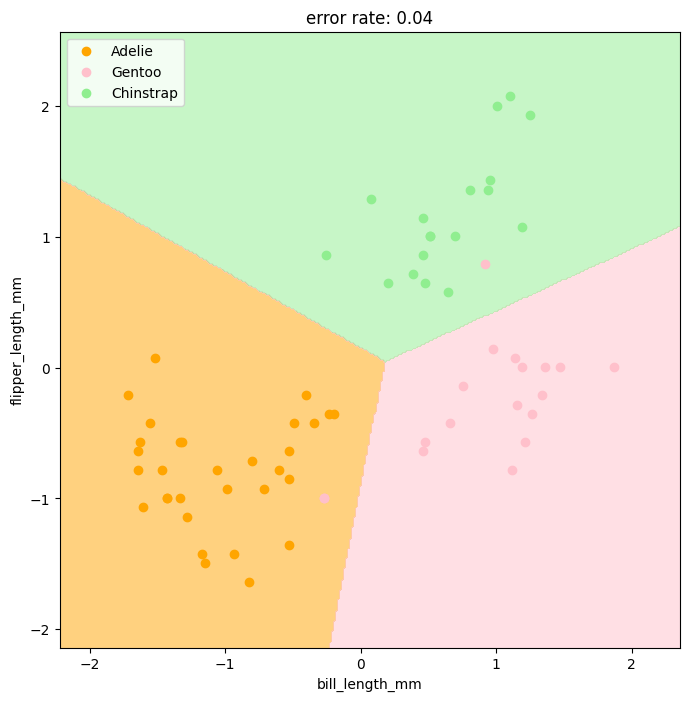

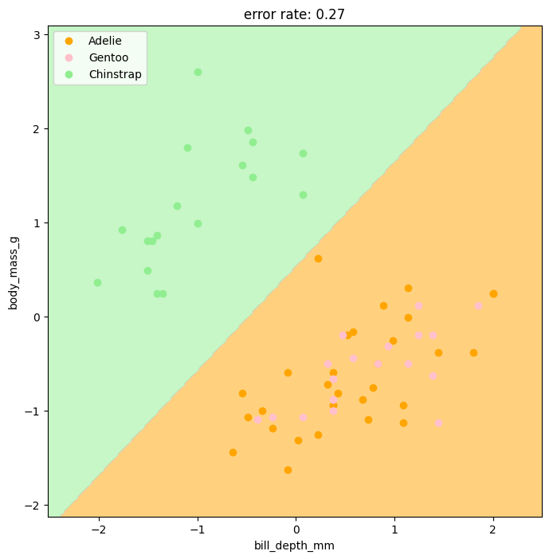

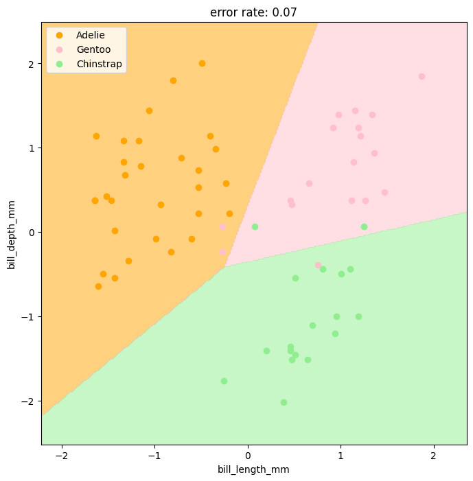

```python
# Your code and markdown here
additional_pairs = [
    ("bill_depth_mm", "body_mass_g"),
    ("bill_length_mm", "bill_depth_mm")
]
pairs_to_plot = [best_pair] + additional_pairs
for pair in pairs_to_plot:
    X_pair = X[list(pair)]
    X_train, X_test, y_train, y_test = train_test_split(
        X_pair, y, train_size=0.8, random_state=42
    )
    lr = LogisticRegression(solver="lbfgs", max_iter=100)
    lr.fit(X_train, y_train)
    y_pred = lr.predict(X_test)
    error_rate = 1 - accuracy_score(y_test, y_pred)

    plot_decision_boundaries(X_test, y_test, lr, error_rate)
    plt.show()
```

Is it what you expected? Where are you observing incorrect predictions? Describe why the decision boundaries make sense, from your understanding of the logistic regression model.

This is exaclty what I expected. I'm observing incorrect predictions primarily with the orange region of the body mass vs bill depth plot, and a couple of outliers with the other plots as well. The decision boundaries make sense because logistic regression aims to optimize classification error by drawing straight lines that split up the data into distinct classes, and that's exactly what we see here.

### 1.6 (Optional) Use different regularization levels (2 points EC)

Now that you have a working logistic regression algorithm, explore how to set the regularization level $C=1/\lambda$. Use an appropriate cross-validation procedure to choose the regularization level, and explain your results.

```
The best value of C is 21.54434690031882 with a cross-validation accuracy of 0.9970
```

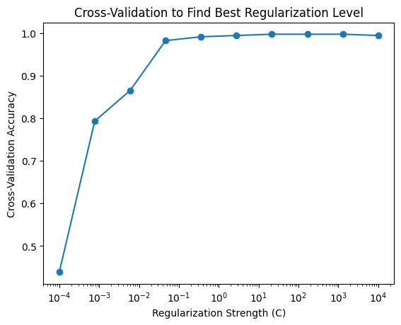

```python
# Your code and markdown here
from sklearn.model_selection import cross_val_score

C_values = np.logspace(-4, 4, 10)  # Try values of C from 0.0001 to 10000
cv_scores = []
for C in C_values:
    lr = LogisticRegression(
        solver="lbfgs", C=C, max_iter=500
    )
    scores = cross_val_score(lr, X, y, cv=5, scoring="accuracy")
    cv_scores.append(scores.mean())

best_C = C_values[np.argmax(cv_scores)]
best_score = max(cv_scores)

print(
    f"The best value of C is {best_C} with a cross-validation accuracy of {best_score:.4f}"
)

plt.plot(C_values, cv_scores, marker="o")
plt.xscale("log")
plt.xlabel("Regularization Strength (C)")
plt.ylabel("Cross-Validation Accuracy")
plt.title("Cross-Validation to Find Best Regularization Level")
plt.show()
```

If C is too large the model overfits, if C is too small the model underfits. It appears that around 21.5 is the sweet spot.

Hooray! You are now a penguin master!

## Problem 2: Mini-Batch Gradient Descent (25 points)

Consider a univariate logistic regression where we are trying to predict $Y$, which can take the value $0$ or $1$, from the variable $X$, which takes real values. Recall from lecture that we need to estimate parameters $\beta_{0}$ and $\beta_{1}$ by minimizing the penalized loss function:

$L(\beta_{0}, \beta_{1}) = \frac{1}{n}\sum\limits_{i=1}^{n} \left[ log\left( 1 + e^{\beta_{0} + X_{i}\beta_{1}}\right) - Y_{i}\left(\beta_{0} + X_{i}\beta_{1}\right)\right] + \lambda \beta_{1}^{2}$ .

Note that generally the intercept is not penalized.

In this problem, we will implement mini-batch gradient descent. At each iteration, a random set of $m$ samples from all $n$ samples is used to calculate the loss and gradient, which is the change in the loss with respect to the parameters. We then update the estimates of $\beta_{0}$ and $\beta_{1}$ based on the gradient.

Run the next cell to simulate data using the parameter values of $\beta_{0} = 3$ and $\beta_{1} = -5$.

```python
n = 10000
np.random.seed(265)
x1 = np.random.uniform(-5, 5, size=n)
beta0 = 3
beta1 = -5
p = np.exp(beta0 + x1*beta1)/(1 + np.exp(beta0 + beta1*x1))
y = np.random.binomial(1, p, size=n)
```

Here is a helper function for plotting we'll use later. Just run this cell; don't change it.

```python
def plot_betas_and_loss(beta0_all, beta1_all, loss_all, title=''):
    fig, ax = plt.subplots(1, 3, figsize=(18,5))
    ax[0].plot(np.arange(len(beta0_all)), beta0_all)
    ax[0].hlines(beta0, xmin=0, xmax=len(beta0_all),color = 'r')
    ax[0].set_xlabel("Iteration", fontsize=12)
    ax[0].set_ylabel(r"$\widehat{\beta}_{0}$", fontsize=12)

    ax[1].plot(np.arange(len(beta1_all)), beta1_all)
    ax[1].hlines(beta1, xmin=0, xmax=len(beta1_all),color = 'r')
    ax[1].set_xlabel("Iteration", fontsize=12)
    ax[1].set_ylabel(r"$\widehat{\beta}_{1}$", fontsize=12)
    ax[1].set_title(title)

    ax[2].plot(np.arange(len(loss_all)), loss_all)
    ax[2].set_xlabel("Iteration", fontsize=12)
    ax[2].set_ylabel("Loss", fontsize=12)
    plt.show()
```

### 2.1 Deriving the updates

Let $L_{t}(\beta_{0}, \beta_{1})$ be the loss at $t$-th iteration. For given values of $\beta_{0}$ and $\beta_{1}$, the vector $\left( \dfrac{\partial}{\partial \beta_{0}} L_{t}(\beta_{0}, \beta_{1}), \dfrac{\partial}{\partial \beta_{1}} L_{t}(\beta_{0}, \beta_{1}) \right)^{T}$ is called the gradient of $L_{t}(\beta_{0}, \beta_{1})$ and is denoted $\nabla L_{t}(\beta_{0}, \beta_{1})$.

We calculate the derivative of $L_{t}(\beta_{0}, \beta_{1})$ with respect to $\beta_{0}$, treating $\beta_{1}$ as a constant. (i.e. calculate $\dfrac{\partial}{\partial \beta_{0}} L_{t}(\beta_{0}, \beta_{1})$):

$\dfrac{\partial}{\partial \beta_{0}} L(\beta_{0}, \beta_{1}) = \frac{1}{n}\sum\limits_{i=1}^{n} \left(\dfrac{e^{\beta_{0} + X_{i}\beta_{1}}}{1+e^{\beta_{0} + X_{i}\beta_{1}}}- Y_{i}\right)$.

Now calculate the derivative of $L_{t}(\beta_{0}, \beta_{1})$ with respect to $\beta_{1}$, treating $\beta_{0}$ as a constant. (i.e. calculate $\dfrac{\partial}{\partial \beta_{1}} L_{t}(\beta_{0}, \beta_{1})$).

Be sure to show your work by either typing it in here using LaTeX, or by taking a picture of your handwritten solutions and displaying them here in the notebook. (If you choose the latter of these two options, be sure that the display is large enough and legible. Please also upload a photo seperately to Gradescope in case the embedded image failed.)

**[put your solution here]**

$$ \frac{\partial}{\partial \beta_1} \log \left( 1 + e^{\beta_0 + X_i \beta_1} \right) = \frac{e^{\beta_0 + X_i \beta_1}}{1 + e^{\beta_0 + X_i \beta_1}} \cdot X_i $$

$$ \frac{\partial}{\partial \beta_1} \left( -Y_i \left( \beta_0 + X_i \beta_1 \right) \right) = -Y_i X_i $$

$$ \frac{\partial}{\partial \beta_1} L_{t}(\beta_0, \beta_1) = \frac{1}{n} \sum_{i=1}^{n} \left( \frac{e^{\beta_0 + X_i \beta_1}}{1 + e^{\beta_0 + X_i \beta_1}} \cdot X_i - Y_i X_i \right) $$

$$ \frac{\partial}{\partial \beta_1} \lambda \beta_1^2 = 2 \lambda \beta_1 $$

$$ \frac{\partial}{\partial \beta_1} L(\beta_0, \beta_1) = \frac{1}{n} \sum\limits_{i=1}^{n} \left( \frac{e^{\beta_0 + X_i \beta_1}}{1 + e^{\beta_0 + X_i \beta_1}} \cdot X_i - Y_i X_i \right) + 2 \lambda \beta_1 $$

When we implement mini-batch stochastic gradient descent, we will use these formulas, but apply them to a mini-batch of $m$ randomly chosen datapoints, rather than to all $n$ datapoints (in our case $n=10,000$). Typically $m$ is chosen to be much, much smaller than $n$.

### 2.2 The key ingredients

Complete the function `update` in the following cell which takes values for $\beta_{0}$ and $\beta_{1}$, a list `inds` containing the indexes of the $m$ selected samples, as well as a step-size $\eta$, and returns updated values for $\beta_{0}$ and $\beta_{1}$ from one step of gradient descent (using all the data and your answer to Part a).

```python
def update(b0, b1, inds, step_size, lamb):
    m = len(inds)

    L_partial0 = 0
    L_partial1 = 0

    for i in inds:
        Xi = x1[i]
        Yi = y[i]
        z = b0 + Xi * b1
        L_partial0 += (np.exp(z) / (1 + np.exp(z))) - Yi
        L_partial1 += ((np.exp(z) / (1 + np.exp(z))) - Yi) * Xi

    L_partial0 /= m
    L_partial1 /= m
    L_partial1 += 2 * lamb * b1
    return (b0 - step_size * L_partial0, b1 - step_size * L_partial1)
```

Now complete the function in the next cell called `loss` which takes values for $\beta_{0}$ and $\beta_{1}$, together with a subset of indices and regularization parameter, and returns the value of the loss function evaluated at those data points.

```python
def loss(b0, b1, inds, lamb):
    m = len(inds)
    loss_value = 0
    for i in inds:
        Xi = x1[i]
        Yi = y[i]
        z = b0 + Xi * b1

        loss_value += np.log(1 + np.exp(z)) - Yi * z
    loss_value /= m
    loss_value += lamb * b1**2
    return loss_value
```

### 2.3 Putting it all together

Now complete the implementation of `minibatch_grad_descent` which puts all of these pieces together

```python
def minibatch_grad_descent(
    b0=0, b1=0, batch_size=100, step_size=10, lamb=0, iterations=1000
):
    beta0_hat = b0
    beta1_hat = b1
    beta0_all = []
    beta1_all = []
    loss_all = []

    for iter in range(iterations):
        inds = np.random.choice(range(len(x1)), size=batch_size, replace=False)
        batch_loss = loss(beta0_hat, beta1_hat, inds, lamb)
        beta0_hat, beta1_hat = update(beta0_hat, beta1_hat, inds, step_size, lamb)

        beta0_all.append(beta0_hat)
        beta1_all.append(beta1_hat)
        loss_all.append(batch_loss)

    return (beta0_hat, beta1_hat, beta0_all, beta1_all, loss_all)
```

Now, test your implementation by running the following cell, which will call the function with the default parameters, and then plot the beta parameters and loss during the course of stochastic gradient descent. We will check your plot as a first check that you have a correct implementation! You should expect the first plot looks like the following:

[figure not shown]

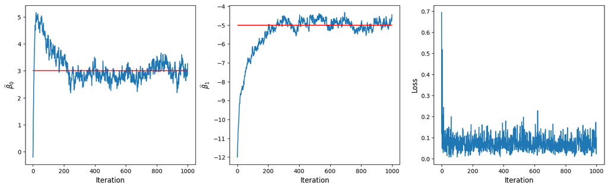

```python
# Run this cell, don't change it!

beta0_hat, beta1_hat, beta0_all, beta1_all, loss_all = minibatch_grad_descent()
plot_betas_and_loss(beta0_all, beta1_all, loss_all)
```

### 2.4 Assessing uncertainty

We now use the code above that implements mini-batch gradient descent and run it several (30) times. We then display the mean and standard deviation of the estimates.

```python
# run this cell, don't change it

from tqdm import tqdm

beta0_hat_all_0 = []
beta1_hat_all_0 = []
for rep in tqdm(range(30)):
    beta0_hat, beta1_hat, _, _, _ = minibatch_grad_descent()
    beta0_hat_all_0.append(beta0_hat)
    beta1_hat_all_0.append(beta1_hat)

print('The mean of the estimated beta0 is %.2f' % np.mean(beta0_hat_all_0))
print('The standard deviation of the estimated beta0 is %.3f' % np.std(beta0_hat_all_0))
print('The mean of the estimated beta1 is %.2f' % np.mean(beta1_hat_all_0))
print('The standard deviation of the estimated beta1 is %.3f' % np.std(beta1_hat_all_0))
```

```
The mean of the estimated beta0 is 2.82
The standard deviation of the estimated beta0 is 0.255
The mean of the estimated beta1 is -4.83
The standard deviation of the estimated beta1 is 0.228
```

Comment on these results:

1. Describe what causes the variation in the estimates.
2. How would you construct approximate 95% confidence intervals for the estimates?
3. Do the true parameters fall in those confidence intervals?

**[Put your answers in this markdown cell]**

1. Mini-batch gradient descent is by nature stochastic. Each time the algorithm runs, a different random mini-batch of data points is selected for each iteration. This randomness introduces variability in the gradient estimates, and therefore, the final parameter estimates after gradient descent.
2. To construct 95% confidence intervals for $\beta_0$ and $\beta_1$, we use the formula:

$$ \text{CI} = \left( \hat{\beta} - 1.96 \cdot \text{STD}, \hat{\beta} + 1.96 \cdot \text{STD} \right) $$

For $\beta_0$:

- Mean: 2.82
- Standard deviation: 0.255 $$ (2.82 - 1.96 \times 0.255, 2.82 + 1.96 \times 0.255) \approx (2.32, 3.32) $$

For $\beta_1$:

- Mean: -4.83
- Standard deviation: 0.228 $$ (-4.83 - 1.96 \times 0.228, -4.83 + 1.96 \times 0.228) \approx (-5.28, -4.38) $$
3. The true parameters do fall within the approximate 95% confidence intervals based on the estimates from these 30 runs

### 2.5 Comparing regularization levels

Repeat 2.3 with different $\lambda$ (the regularization level), e.g. $\lambda=0$, $\lambda=.001$, and $\lambda=.005$. Use (0,0) as the initial estimates of $\beta_{0}$ and $\beta_{1}$. Plot $\beta_{0}$, $\beta_{1}$, and $L(\beta_{0}, \beta_{1})$ vs. iteration number. How do the plots change as you change $\lambda$? Are the changes consistent with your expectation? Why or why not?

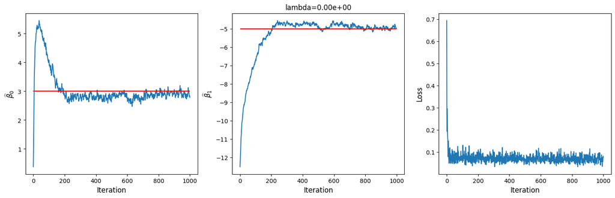

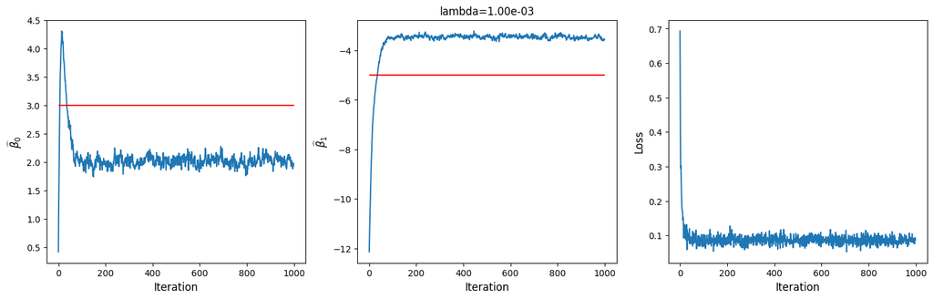

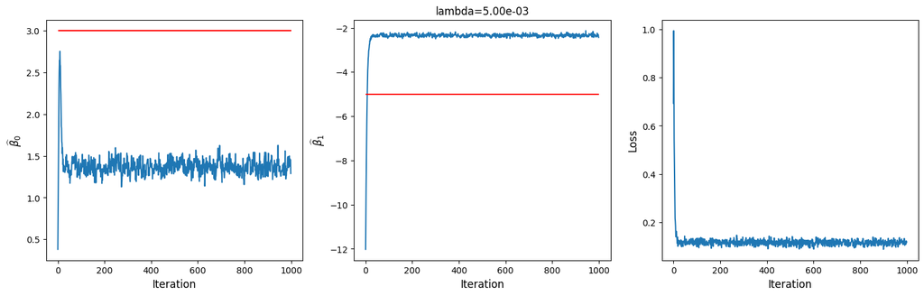

```python
# run this cell, don't change it

for lamb in [0, .001, .005]:
    _, _, beta0_all, beta1_all, loss_all = minibatch_grad_descent(batch_size=500, lamb=lamb)
    plot_betas_and_loss(beta0_all, beta1_all, loss_all, title = 'lambda=%.2e' % lamb)
```

Comment on these results:

1. Describe what causes the differences in the plots across the three regularization levels.
2. Does one of the three runs give a better estimate than the others? Why or why not?

**[Put your answers in this markdown cell]**

1. The differences came from the strength of the regularization level applied.
2. The run where regularization level = 0 gave the best estimate. This is because this is a case where overfitting to the training set is not penalized, so whenever the penalty term shrunk the coefficients toward 0 the estimates became worse.

## Problem 3. Bias and Variance and Trees, Oh My! (20 points)

In this problem you will explore the bias-variance tradeoff for decision trees using a simple toy regression problem. We start by importing a few packages.

```python
import numpy as np
from sklearn.model_selection import train_test_split
from sklearn.tree import DecisionTreeRegressor
import matplotlib.pyplot as plt
%matplotlib inline
```

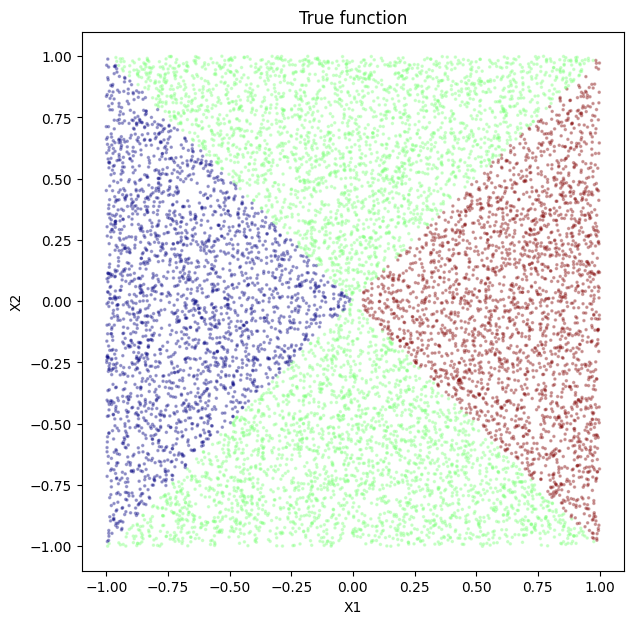

```python
n = 10000
np.random.seed(265)

X = np.random.uniform(low=-1, high=1, size=2*n).reshape(n,2)
f = np.sign(X[:,0] - X[:,1]) + np.sign(X[:,0] + X[:,1])
y = f + np.random.normal(size=n)

fig = plt.figure(figsize=(7,7))
plt.scatter(X[:,0], X[:,1], c=f, alpha=.3, s=2.5, cmap='jet')
plt.xlabel('X1')
plt.ylabel('X2')
_ = plt.title('True function')
```

### 3.1 Build regressions trees with different depth

In this problem you are asked to build a sequence of regression trees using this data, to predict `y` from `x1` and `x2`, varying the tree depth.

- Vary the maximuim tree depth from 1 to 7
- Train each tree on a random set of 500 data points
- Test on the remaining 10000 - 500 data points
- Run 500 trials (train/test splits) for each depth.
- Plot the MSE as a function of the maximum tree depth

The cell below contains some starter code. You may modify this starter code in any way you wish. But be sure to *keep the lines at the end, which plots the mean squared error on the test data versus the depth.*

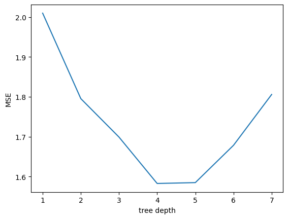

```python
from sklearn.metrics import mean_squared_error

trials = 500
tree_depth = np.arange(1, 8)
test_mean_squared_error = np.zeros(len(tree_depth))

from tqdm import tqdm

for idx, d in enumerate(tqdm(tree_depth)):
    rtree = DecisionTreeRegressor(max_depth=d)
    mse_list = []
    for trial in np.arange(trials):
        train_idx = np.random.choice(n, 500, replace=False)
        test_idx = np.setdiff1d(np.arange(n), train_idx)
        X_train, y_train = X[train_idx], y[train_idx]
        X_test, y_test = X[test_idx], y[test_idx]
        rtree.fit(X_train, y_train)
        y_pred = rtree.predict(X_test)
        mse = mean_squared_error(y_test, y_pred)
        mse_list.append(mse)
    test_mean_squared_error[idx] = np.mean(mse_list)

fig = plt.figure()
plt.plot(tree_depth, test_mean_squared_error)
plt.xlabel("tree depth")
plt.ylabel("MSE")
```

### 3.2 What is the best size of tree?

(a) According to your plot above, what is the best tree depth to choose?

(b) If the regression trees were trained on 5000 data points, rather than 500, how would the choice of tree depth change? Would it increase or decrease? Explain why. Try to answer this question without running any code! If you run an experiment, comment on this in your answer.

[Your answer here in Markdown]

(a) 4

(b) The optimal choice of tree depth would likely increase. Shallow trees tend to have high bias because they are too simple to capture the complexity of the data. Deeper trees can generalize better because they are less likely to overfit to noise. The model would have 10 times more data to learn from if the train set was 5000 data points rather than 500.

### 3.3 Estimate the squared bias and variance

Now estimate the squared bias and variance of the trees as a function of the maximum depth. This is possible in this case because you know the true function `f`, which was defined above. Use the same setup as above:

- Vary the maximuim tree depth from 1 to 7
- Train each tree on a random set of 500 data points
- Run 500 trials for each train/test split.

To estimate the squared bias and variance, evaluate each of the models on each of the $n=10,000$ data points. You can then estimate the squared bias and variance of the predictions $\hat y_i = \hat f(x_i)$ and take the average over all the data points.

Hint: Consider using the fact that the variance of a random variable can be written as $\text{Var}(Z) = \mathbb{E}(Z^2) - \mathbb{E}(Z)^2$. The cell below contains starter code based on this hint. You will need to use the true regression function `f` defined above as a numpy array.

You may modify this starter code in any way you wish. But be sure to *keep the lines at the end, which plots the squared bias and variance.*

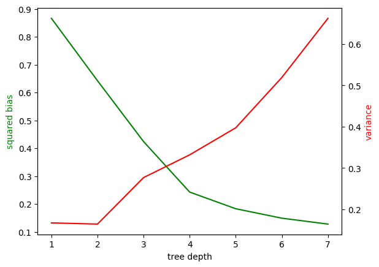

```python
trials = 500
tree_depth = np.arange(1, 8)
bias_squared = []
variance = []

from tqdm import tqdm
for d in tqdm(tree_depth):
    rtree = DecisionTreeRegressor(max_depth=d)
    E_yhat = np.zeros(n)
    E_yhat_squared = np.zeros(n)
    for trial in np.arange(trials):
        train_idx = np.random.choice(n, 500, replace=False)
        X_train, y_train = X[train_idx], y[train_idx]
        rtree.fit(X_train, y_train)
        yhat = rtree.predict(X)
        E_yhat += yhat
        E_yhat_squared += yhat**2
    E_yhat /= trials
    E_yhat_squared /= trials

    bias_squared.append(np.mean((E_yhat - f)**2))
    variance.append(np.mean(E_yhat_squared - E_yhat**2))


fig, ax1 = plt.subplots()
ax2 = ax1.twinx()
ax1.plot(tree_depth, bias_squared, 'g-')
ax2.plot(tree_depth, variance, 'r-')
ax1.set_xlabel('tree depth')
ax1.set_ylabel('squared bias', color='g')
_ = ax2.set_ylabel('variance', color='r')
```

### 3.4 Do the bias and variance make sense?

(a) Explain why your plots of the squared bias and variance make sense, and are consistent with your plot of the MSE computed previously.

(b) What is the (approximate) value of the difference between the MSE and the sum of the squared bias and variance for this data set?

[Your answer here in markdown]

(a) The plots of the squared bias and variance make sense because it fits our understanding of bias decreases and variance increases as depth increases. The MSE is the sum of the squared bias, variance, and noise. The previous MSE plot shows a U-shaped curve, where at first, as depth increases, the MSE decreases; and at higher depths, the MSE starts increasing. In the bias/variance plot, bias dominates at shallow depths, while variance dominates at greater depths, which matches the behavior seen in the MSE plot.